# Basic R Course - Data Cleaning - Answers

**Warning**

Make sure that you try the exercises yourself first before looking at the answers

**Question 1**

What functions are useful for the first exploration of the data? How many observations and variables are in the data set? What type of variables are there?

**Answer 1**

with `dim()` and `str()` we can find out the dimensions of the data and the type of variables. The function `head()` can be used to view the first couple of observations.

```r
dim(R_data)
```

```
[1] 190  20
```

```r
str(R_data)
```

```
'data.frame':   190 obs. of  20 variables:
 $ patientnumber         : int  1 2 3 4 5 6 7 8 9 10 ...
 $ Stauts                : chr  "intellectual disability" "normal brain development" "intellectual disability" "normal brain development" ...
 $ iodine_deficiency     : chr  "no" "no" "no" "yes" ...
 $ BMI                   : int  32 23 29 22 22 24 24 28 33 32 ...
 $ educational_level     : chr  "intermediate" "intermediate" "low" "low" ...
 $ alcohol               : chr  "no" "yes" "no" "no" ...
 $ smoking               : chr  "no" "yes" "no" "no" ...
 $ medication            : chr  "no" "no" "no" "no" ...
 $ birthweight           : int  2618 3541 2619 3810 4136 4030 3377 2500 4255 2952 ...
 $ pregnancy_length_weeks: int  38 40 38 40 42 41 40 37 42 39 ...
 $ pregnancy_length_days : int  4 2 3 5 3 1 4 1 0 2 ...
 $ SAM                   : num  54.5 84 61 43 83 69 79 71.5 56 42.5 ...
 $ SAH                   : num  14.8 23.6 18.7 23.2 17.1 19.6 22.4 18 20 23.4 ...
 $ homocysteine          : num  18.8 15.6 15.2 16.5 19.5 17.5 14.9 22.2 19.1 16 ...
 $ cholesterol           : num  16.5 17.5 16.4 16.4 16.9 15.9 16.9 16 18.6 16.7 ...
 $ HDL                   : num  26.1 26.7 26.2 25.9 26.7 ...
 $ triglycerides         : num  8.84 7.78 7.54 8.95 7.57 7.35 7.63 7.38 8.25 8.27 ...
 $ vitaminB12            : int  303 370 533 346 389 611 604 518 288 520 ...
 $ folicacid_serum       : num  26.4 37.8 33.7 35.1 29 28.3 33.8 31.1 27.7 33.4 ...
 $ folicacid_erys        : num  1132 1467 1528 1539 1178 ...
```

**Question 2**

There is a typo in one of the variable names (`Stauts` instead of `Status`). Change this.

**Answer 2**

```r
names(R_data)[names(R_data) == "Stauts"] <- "Status"
names(R_data)
```

```
 [1] "patientnumber"          "Status"                 "iodine_deficiency"
 [4] "BMI"                    "educational_level"      "alcohol"
 [7] "smoking"                "medication"             "birthweight"
[10] "pregnancy_length_weeks" "pregnancy_length_days"  "SAM"
[13] "SAH"                    "homocysteine"           "cholesterol"
[16] "HDL"                    "triglycerides"          "vitaminB12"
[19] "folicacid_serum"        "folicacid_erys"
```

**Question 3**

Round the variable `folicacid_erys` to two decimals.

Verify by evaluating the first `20` values of this new variables (there are several ways to do this).

**Answer 3**

```r
R_data$folicacid_erys_round <- round(R_data$folicacid_erys, digits = 2)
R_data[1:20, "folicacid_erys_round"]
```

```
 [1] 1132.00 1467.18 1527.81 1539.13 1177.54 1175.00 1396.00 1341.20 1228.52
[10] 1327.22 1110.88 1289.36 1333.85 1329.62 1207.11 1340.00 1173.00 1653.00
[19] 1088.00  970.00
```

**Question 4**

Make a new variable `birthweight_kg` that gives the birth weight in kilo’s. What did you choose for the number of decimals to round the variable?

Verify by evaluating the first `10` values of this new variables (there are several ways to do this).

**Answer 4**

```r
R_data$birthweight_kg <- round(R_data$birthweight/1000, digits = 1)
R_data$birthweight_kg[1:10]
```

```
 [1] 2.6 3.5 2.6 3.8 4.1 4.0 3.4 2.5 4.3 3.0
```

**Question 5**

The variables `pregnancy_length_weeks` and `pregnancy_length_days` together denote the total length of the pregnancy. For example: `pregnancy_length_weeks = 38` and `pregnancy_length_days = 4`, means this patient is pregnant for 38 weeks plus 4 days. Combine the variables to obtain the length of the pregnancy in days.

Verify by evaluating the first `12` values of this new variables (there are several ways to do this).

**Answer 5**

```r
R_data$total_preg_days <- R_data$pregnancy_length_weeks*7 + R_data$pregnancy_length_days
head(R_data$total_preg_days, 12)
```

```
 [1] 270 282 269 285 297 288 284 260 294 275 263 249
```

**Question 6**

Divide the variable `BMI` into categories: `<18.5` (“Underweight”), `18.5 - 24.9` (“Healthy weight”), `25 - 29.9` (“Overweight”), and `>30` (Obesity). How many patients (and %) are in each category?

**Hint**

Use the function `cut()`

**Answer 6**

```r
R_data$BMI_cat <- cut(R_data$BMI, breaks=c(-Inf, 18.5, 24.9, 29.9, Inf),
                       labels=c("Underweight", "Healthy weight", "Overweight", "Obesity"))

table(R_data$BMI_cat)
```

```
   Underweight Healthy weight     Overweight        Obesity
             1            104             76              9
```

```r
prop.table(table(R_data$BMI_cat))
```

```
   Underweight Healthy weight     Overweight        Obesity
   0.005263158    0.547368421    0.400000000    0.047368421
```

**Question 7**

For a current analysis, I am only interested in the patients with “Healthy weight”. Additionally, I only want to look at the relation between `Status` and `birthweight`. Make a data set with only these two variables and `patientnumber`, for a subset of the data with the patients with “Healthy weight”.

What are the dimensions of this data set? First try to think yourself and then check with R code.

**Hint**

Give this data set a different name, so you don’t overwrite the original data set.

**Answer 7**

Other solutions might be possible!

```r
R_data2 <- R_data[R_data$BMI_cat == "Healthy weight", c("patientnumber","Status", "birthweight")]

str(R_data2)
```

```
'data.frame':   104 obs. of  3 variables:
 $ patientnumber: int  2 4 5 6 7 14 16 19 20 21 ...
 $ Status       : chr  "normal brain development" "normal brain development" "intellectual disability" "intellectual disability" ...
 $ birthweight  : int  3541 3810 4136 4030 3377 2828 2959 3383 2500 2720 ...
```

```r
dim(R_data2)
```

```
[1] 104   3
```

**Question 8**

Make a third data set containing the variables: `patientnumber`, `Status` and `BMI`. Then merge the data set you created in Question 7 with this data set.

Merging these two data sets can be done several different ways. Describe two ways. What are the dimensions of these data sets?

**Hint**

For these two data sets inner join and left join will give the same results. The same goes for right join and full join.

**Answer 8**

```r
R_data3 <- R_data[, c("patientnumber","Status", "BMI")]


data_inner <- merge(R_data2, R_data3, by = c("patientnumber", "Status"))
data_right <- merge(R_data2, R_data3, by = c("patientnumber", "Status"), all.y = T)


dim(data_inner)
```

```
[1] 104   4
```

```r
dim(data_right)
```

```
[1] 190   4
```

**Question 9**

There are several biomarkers collected in the data set. Investigate whether there are outliers in the biomarkers: `cholesterol`, `triglycerides`, and `vitaminB12`. Which functions did you use?

**Answer 9**

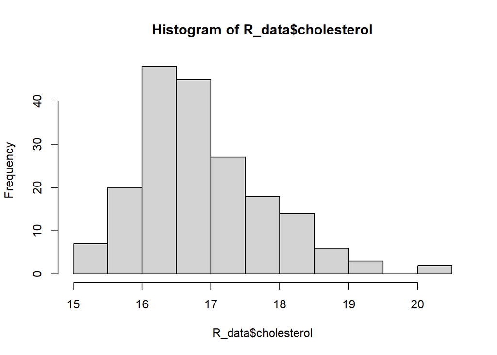

```r
# Cholesterol
hist(R_data$cholesterol)
```

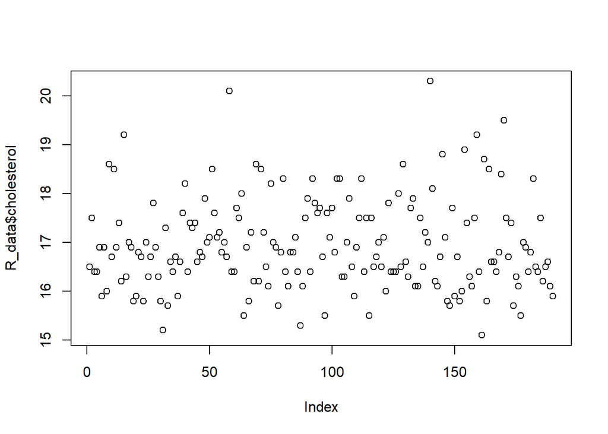

```r
plot(R_data$cholesterol)
```

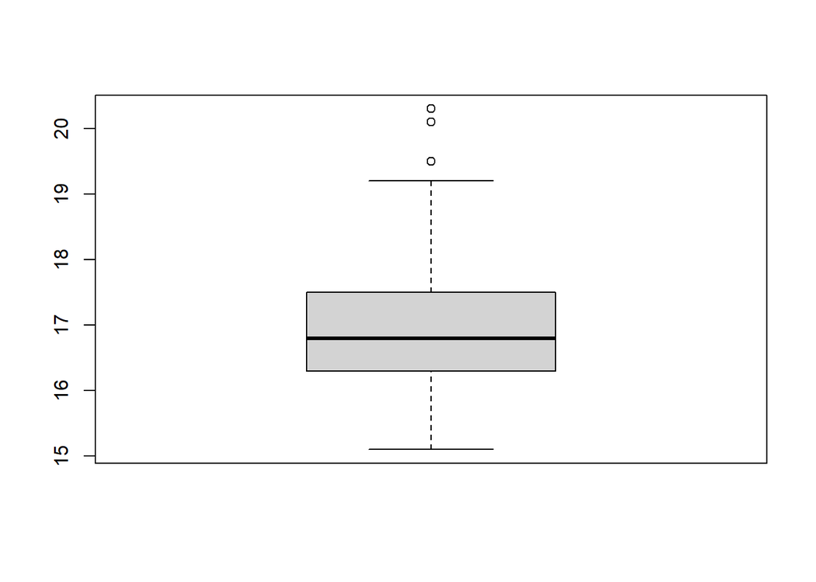

```r
boxplot(R_data$cholesterol)
```

```r
summary(R_data$cholesterol)
```

```
   Min. 1st Qu.  Median    Mean 3rd Qu.    Max.
  15.10   16.30   16.80   16.94   17.50   20.30
```

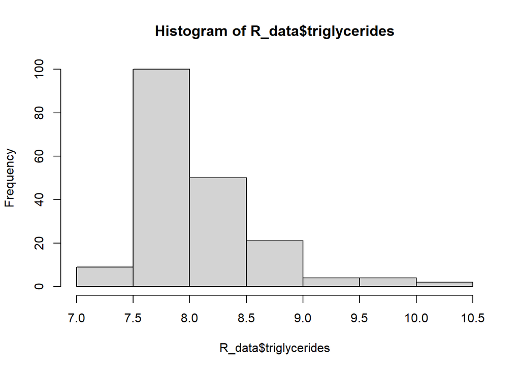

```r
# triglycerides
hist(R_data$triglycerides)
```

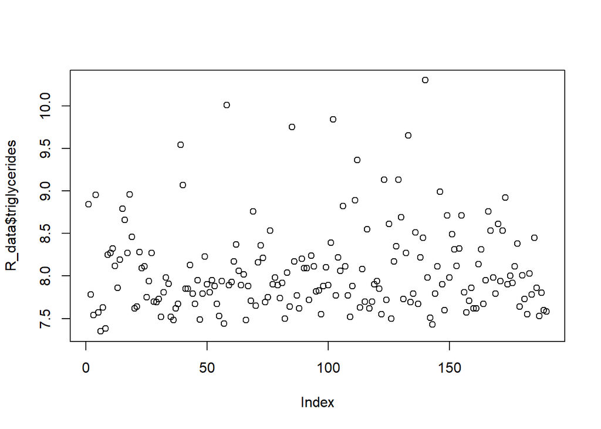

```r
plot(R_data$triglycerides)
```

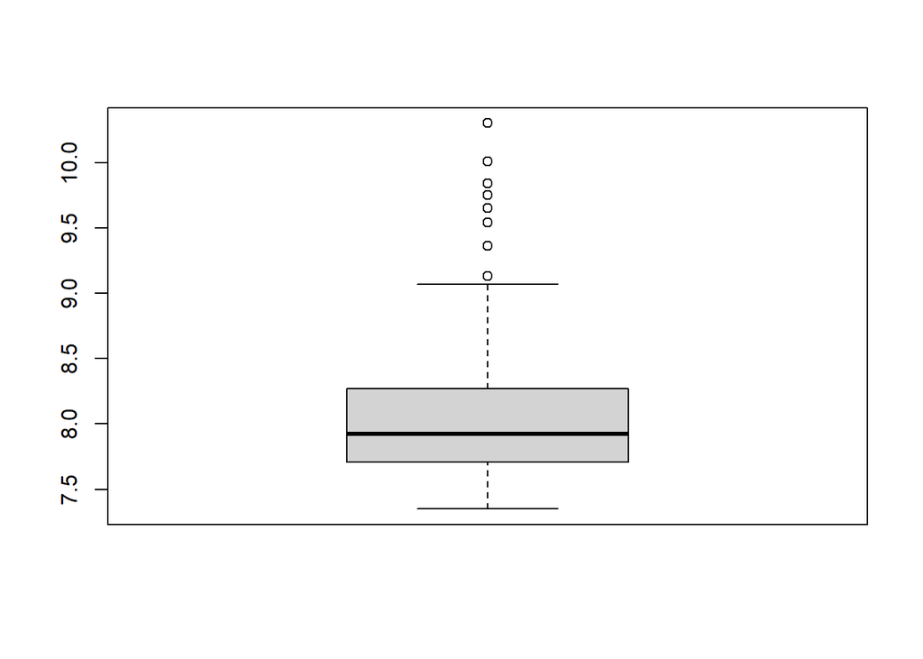

```r
boxplot(R_data$triglycerides)
```

```r
summary(R_data$triglycerides)
```

```
   Min. 1st Qu.  Median    Mean 3rd Qu.    Max.
  7.350   7.710   7.925   8.068   8.270  10.300
```

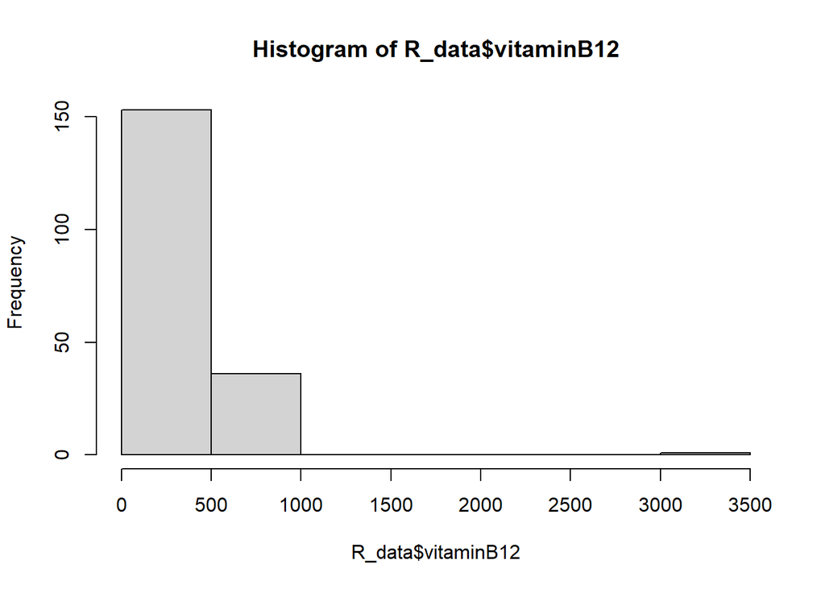

```r
# vitaminB12
hist(R_data$vitaminB12)
```

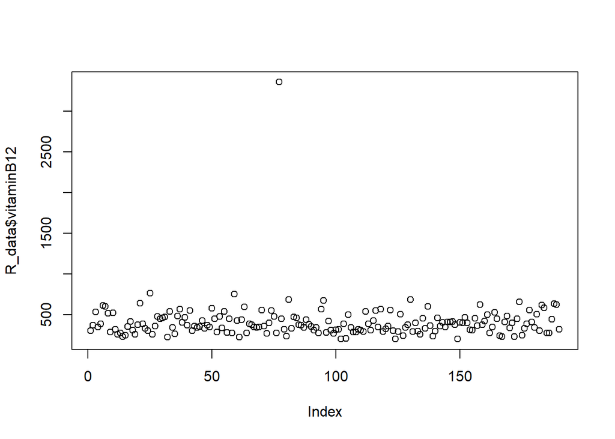

```r
plot(R_data$vitaminB12)
```

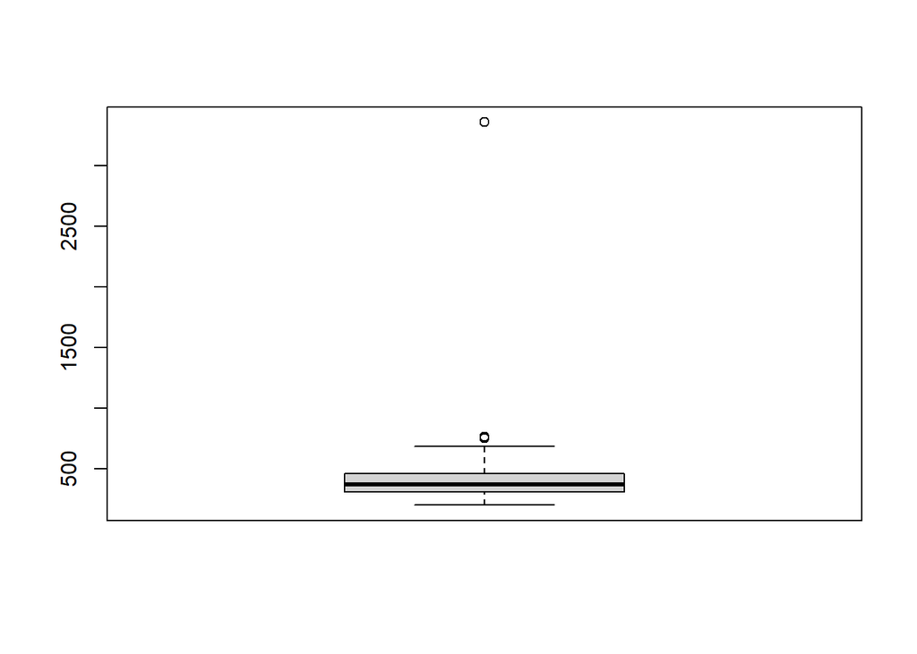

```r
boxplot(R_data$vitaminB12)
```

```r
summary(R_data$vitaminB12)
```

```
   Min. 1st Qu.  Median    Mean 3rd Qu.    Max.
  201.0   307.0   370.5   409.7   463.0  3360.0
```

There is one outlier in vitaminB12.

**Question 10**

In question 9 we found an outlier. How do you deal with this outlier?

**Answer 10**

Knowing that the value of `3360` is an impossible value for vitamin B12, we can decide to remove this measurement. We can either put this measurement to missing (NA)

```r
R_data$vitaminB12_cor <- R_data$vitaminB12
R_data$vitaminB12_cor[R_data$vitaminB12_cor  == 3360] <- NA
summary(R_data$vitaminB12_cor)
```

```
   Min. 1st Qu.  Median    Mean 3rd Qu.    Max.    NA's
  201.0   307.0   370.0   394.1   463.0   766.0       1
```

or we can remove the whole patient

```r
R_data_cor <- R_data[R_data$vitaminB12 != 3360,]
dim(R_data_cor)
```

```
[1] 189  25
```

**Question 11**

Fill in the table with summary statistics below

|  |  | Intellectual disability | Normal brain development |
| --- | --- | --- | --- |
|  |  | (n = …) | (n = …) |
| BMI, median [IQR] |  |  |  |
|  | missing (n = ) |  |  |
| Educational level | Low, n(%) |  |  |
|  | Intermediate, n(%) |  |  |
|  | High, n(%) |  |  |
|  | missing (n = ) |  |  |
| Smoking | No, n(%) |  |  |
|  | Yes, n(%) |  |  |
|  | missing (n = ) |  |  |
| SAM, mean (SD) |  |  |  |
|  | missing (n = ) |  |  |
| SAH, median [IQR] |  |  |  |
|  | missing (n = ) |  |  |
| Vitamin B12, median [IQR] |  |  |  |
|  | missing (n = ) |  |  |

**Hint**

You can change the order of factors

`R_data$educational_level <- factor(R_data$educational_level, levels = c('low', 'intermediate', 'high'))`

**Answer 11**

```r
table(R_data$Status)

aggregate(BMI ~ Status, data = R_data, summary)
R_data$educational_level <- factor(R_data$educational_level, levels = c('low', 'intermediate', 'high'))
with(R_data, table(educational_level, Status))
prop.table(with(R_data, table(educational_level, Status)),2)

with(R_data, table(smoking, Status))
prop.table(with(R_data, table(smoking, Status)),2)

aggregate(SAM ~ Status, data = R_data, mean)
aggregate(SAM ~ Status, data = R_data, sd)

aggregate(SAH ~ Status, data = R_data, summary)

aggregate(vitaminB12_cor ~ Status, data = R_data, summary)
```

|  |  | Intellectual disability | Normal brain development |
| --- | --- | --- | --- |
|  |  | (n = *82*) | (n = *108*) |
| BMI, median [IQR] |  | *24 [22 - 27]* | *24 [22 - 26]* |
|  | missing (n = *0* ) |  |  |
| Educational level | Low, n(%) | *31 (38%)* | *14 (13%)* |
|  | Intermediate, n(%) | *34 (41%)* | *48 (44%)* |
|  | High, n(%) | *17 (21%)* | *46 (43%)* |
|  | missing (n = *0*) |  |  |
| Smoking | No, n(%) | *55 (67%)* | *96 (89%)* |
|  | Yes, n(%) | *27 (33%)* | *12 (11%)* |
|  | missing (n = *0*) |  |  |
| SAM, mean (SD) |  | *72 (16)* | *75 (18)* |
|  | missing (n = *0*) |  |  |
| SAH, median [IQR] |  | *16 [15 - 18]* | *18 [16 - 20]* |
|  | missing (n = *0*) |  |  |
| Vitamin B12, median [IQR] |  | *378 [310 - 477]* | *363 [305 - 449]* |
|  | missing (n = *1*) |  |  |